# Session 2: Time

Why a spacecraft needs an SCLK kernel

SPICE Book Club · LASP

## A packet arrives from Mars

The MAVEN header says the data were taken at

SCLK 3/0812345678.32768

**When was that, in UTC? And where was MAVEN?**

To answer, SPICE needs two pieces of knowledge that live in kernels:

- how Earth’s civil time relates to uniform physical time → **LSK**
- how *this spacecraft’s* clock relates to physical time → **SCLK**

Today: where those two files come from, and why they look the way they do.

## Two ways to count time

**Solar time (UT1)**

- Noon = Sun over the prime meridian
- Follows Earth’s rotation, which is irregular and slowing (~ms per day)
- What humans live by

**Atomic time (TAI)**

- Weighted average of hundreds of atomic clocks worldwide
- Every second is an SI second (cesium-133)
- Perfectly uniform, ignores the Sun

**UTC** ticks atomic seconds but inserts *leap seconds* to stay within 0.9 s of UT1.

## The cost of the compromise: leap seconds

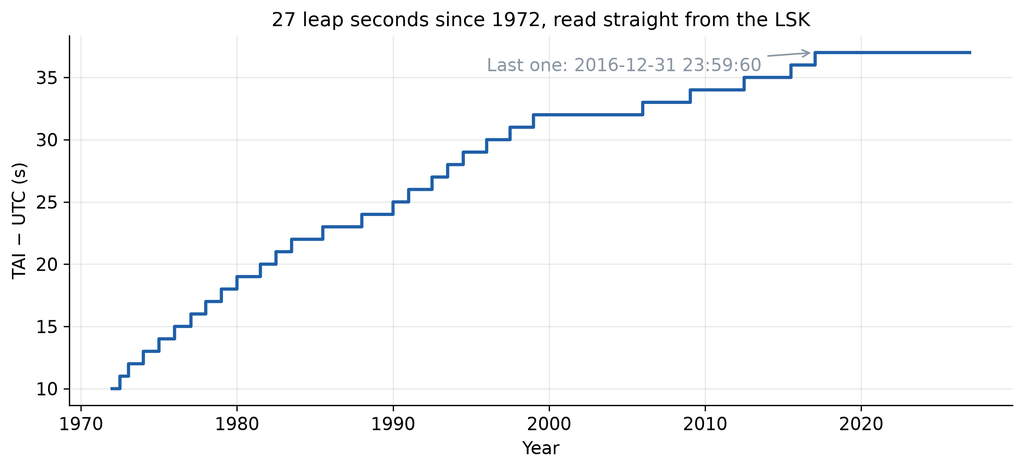

A leap-second day has 86 401 seconds. In 2022 the CGPM decided to let UT1 − UTC grow beyond 1 s by 2035, effectively ending leap seconds; the LSK still matters for every date before then.

## Time for physics: TT, TDB and ET

```
flowchart LR
  UTC["UTC<br/>civil time"] -->|"+ leap seconds<br/>(LSK table)"| TAI["TAI<br/>atomic"]
  TAI -->|"+ 32.184 s<br/>(fixed)"| TT["TT / TDT<br/>Earth-surface<br/>proper time"]
  TT -->|"+ periodic term<br/>≤ 1.7 ms"| TDB["TDB = ET<br/>solar-system<br/>barycentric"]
```

- Equations of motion need a uniform time at the solar-system barycenter: **TDB**.
- **ET** in SPICE = TDB seconds past J2000 (2000-01-01 12:00:00 TDB).
- UTC is only an *input/output format*; SPICE computes in ET.
- Everything on this slide is in the LSK — four numbers plus the leap-second table.

## In SpiceyPy

```python
et = sp.str2et("2016-12-31T23:59:60")          # UTC string -> ET (TDB s past J2000)
print(f"ET            = {et:,.3f} s")
print(f"ET - UTC      = {sp.deltet(et, 'ET'):.6f} s")
print(f"one second on = {sp.et2utc(et + 1, 'ISOC', 3)}")
print(f"as DOY        = {sp.timout(et, 'YYYY-DOY // HR:MN:SC.### ::UTC')}")
```

```
ET            = 536,500,868.184 s
ET - UTC      = 68.183930 s
one second on = 2017-01-01T00:00:00.000
as DOY        = 2016-366 // 23:59:60.000
```

Rule of thumb: convert to ET at the edge of your program, do all arithmetic in ET, convert back to UTC only for display.

## How a spacecraft keeps time

```
flowchart LR
  OSC["Crystal oscillator<br/>(oven-controlled)"] --> CNT["Counter<br/>seconds : subticks"]
  CNT --> FSW["Flight software<br/>distributes time"]
  FSW --> PKT["Every telemetry packet<br/>stamped with SCLK"]
  FSW --> CMD["Stored commands<br/>execute on SCLK"]
```

- No GPS in deep space and no atomic clock on most missions.
- The counter just counts oscillator cycles since some epoch or reset.
- An on-board “second” is whatever the oscillator says it is.

## Reading a clock string: MAVEN

`3/0812345678.32768`

| Field | Meaning | Modulus |
| --- | --- | --- |
| 1 | whole on-board seconds | 4 294 967 296 (2³²) |
| 2 | subticks of 1/65 536 s | 65 536 |

- `.32768` is **32768 / 65536 = 0.5 s**, not 0.32768 s
- One *tick* = 1/65 536 s ≈ 15.3 µs

From `MVN_SCLKSCET.00133.tsc`:

```
SCLK01_N_FIELDS_202  = ( 2 )
SCLK01_MODULI_202    = ( 4294967296
                         65536 )
SCLK01_OFFSETS_202   = ( 0 0 )
SCLK01_TIME_SYSTEM_202 = ( 2 )
```

`202` is MAVEN’s clock ID (spacecraft −202). Time system 2 = TDT (TT).

## Clocks drift

- Oscillator frequency shifts with **temperature**, **aging** and **radiation**.
- Small fractional errors add up fast:

≈ 2 ppm

MAVEN’s current rate: 1.0000020 TT s per clock second

≈ 0.17 s/day

how far MAVEN’s clock falls behind TT each day

So “SCLK + 86 400” is **not** one day later. Convert to ET, add, convert back.

## Correlation: measuring the drift

```
sequenceDiagram
  participant SC as MAVEN
  participant DSN as DSN station
  participant Ops as Ground ops
  SC->>DSN: frame stamped SCLK = s
  Note over SC,DSN: one-way light time 4–22 min
  DSN->>Ops: received at UTC r
  Ops->>Ops: sent at r − OWLT − station/transponder delays
  Ops->>Ops: record pair (s, TT)
```

Thousands of these pairs over weeks give a drift history.

## The model: piecewise-linear segments

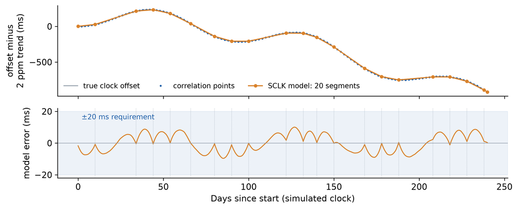

Simulated clock: 2 ppm mean drift (≈ 41 s over 240 days, removed in the top panel) plus a 90-day thermal cycle. A new segment starts whenever a straight line can no longer stay within tolerance.

## That table *is* the SCLK kernel

Last rows of `SCLK01_COEFFICIENTS_202` in `MVN_SCLKSCET.00133.tsc` (147 rows in total):

```
    SCLK (ticks)          TT (s past J2000)       rate (TT s / clock s)
5.2781429716173E+13     8.0538118401500E+08     1.0000020628093E+00
5.2854406018253E+13     8.0649471631200E+08     1.0000020810872E+00
5.3088007976141E+13     8.1005920673000E+08     1.0000020691935E+00
5.3296981439693E+13     8.1324789532800E+08     1.0000019830000E+00
```

Each row starts a segment. For a tick count *s* inside it:

TT(*s*) = TT<sub>0</sub> + rate × (*s* − *s*<sub>0</sub>) / 65 536

`scs2e` finds the segment, applies the line, and converts TT → TDB (ET).

## Partitions: when the clock resets

- A reset, rollover or “jam” breaks the count → start a new **partition**.
- Clock strings carry the partition: `3/0812345678.32768`.
- MAVEN has **3 partitions** (pre-launch and early cruise; 2013-12 to early 2022; current).

```
SCLK_PARTITION_START_202 = ( 0.0000000000000E+00
                             2.8794165854208E+13
                             4.5804921290752E+13 )
```

## Three ways LASP missions handle drift

| Strategy | Example missions | Trade-off |
| --- | --- | --- |
| Discipline the clock to GPS | MMS, IXPE | Easiest; GPS only near Earth |
| Adjust the on-board clock | SORCE (formerly AIM) | Small time jumps on board; ground model stays simple |
| Leave the clock alone; model it on the ground | MAVEN, EMM, Kepler | Clean on-board time; ground needs an up-to-date SCLK |

From the LASP *Time* presentation (Bershenyi/Moffatt, 2026).

## Why it matters

7.5 m

along-track error per **1 ms** of timing error in LEO (7.5 km/s)

~700 m

MAVEN near periapsis (~4 km/s) if one day of drift (0.17 s) were ignored

- Pointing error scales with slew rate the same way.
- CK attitude is indexed by SCLK: a stale SCLK mis-times *and* mis-points.

## In SpiceyPy (notebook 02)

```python
sp.furnsh(["naif0012.tls", "MVN_SCLKSCET.00133.tsc"])

et  = sp.scs2e(-202, "3/0812345678.32768")   # clock string -> ET
utc = sp.et2utc(et, "ISOC", 3)
clk = sp.sce2s(-202, et)                     # ET -> clock string

coeffs = sp.gdpool("SCLK01_COEFFICIENTS_202", 0, 1000).reshape(-1, 3)
```

Spacecraft ID −202 selects MAVEN’s clock (clock ID 202). Always load the newest SCLK for reprocessing.

## Before next session

**Homework:** notebook `02_time_and_sclk` — time conversions, leap seconds, and plotting MAVEN’s real drift history from the SCLK kernel.

**Reading for Session 3:** tutorial 04 slides 25 and 28–40 (state vectors, aberration corrections), then 18 (SPK); Aberration Corrections Required Reading (intro).

**Discussion now**

- Why won’t SPICE let you add 86 400 to an SCLK and call it “one day later”?
- MAVEN never slews its clock; a smallsat resets from the ground. What changes for your software?
- What breaks in your code if leap seconds stop after 2035?